# 第12回 パイプライン化と実践的データ加工

プログラミング演習Ⅰ

佐藤 秀保

sato0035@toyo.jp

## 準備

授業中のコードはすべてスクリプトに書き実行すること

## 先週までの内容

- dplyrでデータ加工

```r
df1 <- filter(syokudo_data2, 客数 > 0)
df2 <- mutate(df1, 曜日 = weekdays(日付))
df3 <- filter(df2, 曜日 == "Monday")
df4 <- summarise(df3, 客数平均 = mean(客数))
```

１つの加工をするたびにデータフレームに保存するのはダルいのでは…？

## パイプライン化

- パイプ演算子 %>% を用いて，

  **左のもの（データフレーム）を右の関数の第１引数に渡す書き方**
- 例：

```r
#普通の書き方
df_normal <- filter(syokudo_data3, 客数 > 0)
#パイプライン化
df_pipe <- syokudo_data3 %>% filter(客数 > 0)
```

- df_normalとdf_pipeの中身は全く同じ

### 演習の解答をパイプライン化して書く

```r
#普通の書き方
df1 <- filter(syokudo_data3, 客数 > 0)
df2 <- mutate(df1, 曜日 = weekdays(日付))
df3 <- filter(df2, 曜日 == "Monday")
df4 <- summarise(df3, 客数平均 = mean(客数))

#パイプライン化
df <- syokudo_data3 %>%
  filter(客数 > 0) %>%
  mutate(曜日 = weekdays(日付)) %>%
  filter(df2, 曜日 == "Monday") %>%
  summarise(客数平均 = mean(客数))
```

### **パイプ演算子** %>% **の注意点**

```r
#普通の書き方
abs(-2)
#パイプライン化
-2 %>% abs()
```

## 実践的なデータ加工例

### 欠損値NAの直接的扱い

- 「総売上」がNAの行のみを抽出

```r
df5 <- syokudo_data3 %>%
  filter(is.na(総売上))
```

- is.na関数は，欠損値であるか否かをT/Fで判定
- filter関数は，条件式の結果T/Fを受けてTに該当する行のみを抽出
- 「総売上」がNA**でない**行のみを抽出

```r
df6 <- syokudo_data3 %>%
  filter(!is.na(総売上))
```

- ! は否定を表しT/Fが逆転

### グループ別の処理

- 曜日**別**の「総売上」の平均値

```r
df7 <- syokudo_data3 %>%
  mutate(曜日 = weekdays(日付)) %>%
  filter(!is.na(総売上)) %>%
  summarise(総売上の平均 = mean(総売上), .by = 曜日)
```

- .by =というキーワード引数で指定したグループ別に計算が可

（余談：昔は「group_by」という関数を使用しなければグループ別の処理ができなかったが，2023年1月以降，様々な関数内で「.by=」により可能に）

### 値の変換と列の追加

- case_when関数で条件を満たす値を別の値に変換可
- 文法：

  **case_when(条件式１ ~ 条件式1がTRUEの場合に返す値, 条件式２ ~条件式1が FALSEでかつ条件式２がTRUEの場合に返す値, 条件式３ ~ 条件式１と２がFALSEでかつ条件式３がTRUEの場合に返す値, …., TRUE ~ すべての条件式がFALSEの場合に返す値）**
  - 見づらいので実際は適当なところで改行を入れることが多い
- 列追加のmutate関数内での使用が多い
- 例１：「総売上」がその平均値の1.2倍以上なら2，その平均値以上1.2倍未満なら1，それ以外なら0をとる「総売上階級」変数を追加

```r
df8 <- syokudo_data3 %>%
  filter(!is.na(総売上)) %>%
  mutate(総売上階級 = case_when(
    総売上 >= 1.2*mean(総売上) ~ 2,
    総売上 >= mean(総売上) ~ 1,
    TRUE ~ 0)
    )
```

- 例２：月曜日なら1，それ以外の曜日なら0をとる「月曜日ダミー」変数を作成
  - 特定の条件に該当する場合に1，それ以外は0をとる0/1の２値変数はダミー変数とよばれ，データ分析で頻出

```r
df9 <- syokudo_data3 %>%
  mutate(曜日 = weekdays(日付),
         月曜日ダミー = case_when(
           曜日 == "Monday" ~ 1,
           TRUE ~ 0)
         )
```

## 演習

食堂では，客ごとに使用する金額にはそこまで差がないと考えられるため，「総売上が高い日であっても客単価には大差なく，単に客数が多いことが総売上を押し上げる要因だ」と考えているとしよう．

このことを調べるために，まず「客単価」変数（=「総売上」÷「客数」）を作成し，次に，ざっくりと総売上のレベルをわけるために，「総売上」がその平均値の1.2倍以上なら3，平均値の1.2倍未満かつ平均値以上なら2，平均値未満かつ平均値の0.8倍以上なら1，それ以外なら0の「総売上階級」変数を作成，その後「総売上階級」別に「客単価」と「客数」の平均を計算し，「総売上階級」の値の昇順に並び替えよ．

ただし，平均の計算にあたっては欠損値の除外を認め，また，コードを書く際にはパイプ演算子を有効に活用すること．

**完成データフレーム**：

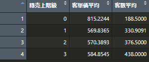

## 課題

- ACEの小テスト：「第12回」
- ACEのレポート：「第12回」
  - ローカルに保存したlecture12.Rを提出